# Data 605 Homework Week-12

## —————————————————————————

### **Student Name :** Sachid Deshmukh

### **Date :** 04/21/2019

- > [GitHub Location for rmd file](https://github.com/mlforsachid/MSDSQ2Data605/blob/master/Week12/HW-12/SachidVijay.Deshmukh60.Rmd)
- > [RPubs location of published file](http://rpubs.com/sachid/Data605Week12HW)

## —————————————————————————

### Multiple Linear Regression

**Load Life Expectancy Data**

```r
life.exp.df = read.csv("https://raw.githubusercontent.com/mlforsachid/MSDSQ2Data605/master/Week12/HW-12/who.csv")
head(life.exp.df)
```

```
##               Country LifeExp InfantSurvival Under5Survival  TBFree
## 1         Afghanistan      42          0.835          0.743 0.99769
## 2             Albania      71          0.985          0.983 0.99974
## 3             Algeria      71          0.967          0.962 0.99944
## 4             Andorra      82          0.997          0.996 0.99983
## 5              Angola      41          0.846          0.740 0.99656
## 6 Antigua and Barbuda      73          0.990          0.989 0.99991
##        PropMD      PropRN PersExp GovtExp TotExp
## 1 0.000228841 0.000572294      20      92    112
## 2 0.001143127 0.004614439     169    3128   3297
## 3 0.001060478 0.002091362     108    5184   5292
## 4 0.003297297 0.003500000    2589  169725 172314
## 5 0.000070400 0.001146162      36    1620   1656
## 6 0.000142857 0.002773810     503   12543  13046
```

```r
str(life.exp.df)
```

```
## 'data.frame':    190 obs. of  10 variables:
##  $ Country       : Factor w/ 190 levels "Afghanistan",..: 1 2 3 4 5 6 7 8 9 10 ...
##  $ LifeExp       : int  42 71 71 82 41 73 75 69 82 80 ...
##  $ InfantSurvival: num  0.835 0.985 0.967 0.997 0.846 0.99 0.986 0.979 0.995 0.996 ...
##  $ Under5Survival: num  0.743 0.983 0.962 0.996 0.74 0.989 0.983 0.976 0.994 0.996 ...
##  $ TBFree        : num  0.998 1 0.999 1 0.997 ...
##  $ PropMD        : num  2.29e-04 1.14e-03 1.06e-03 3.30e-03 7.04e-05 ...
##  $ PropRN        : num  0.000572 0.004614 0.002091 0.0035 0.001146 ...
##  $ PersExp       : int  20 169 108 2589 36 503 484 88 3181 3788 ...
##  $ GovtExp       : int  92 3128 5184 169725 1620 12543 19170 1856 187616 189354 ...
##  $ TotExp        : int  112 3297 5292 172314 1656 13046 19654 1944 190797 193142 ...
```

**1. Provide a scatterplot of LifeExp~TotExp, and run simple linear regression. Do not transform the variables. Provide and interpret the F statistics, R^2, standard error,and p-values only. Discuss whether the assumptions of simple linear regression met.**

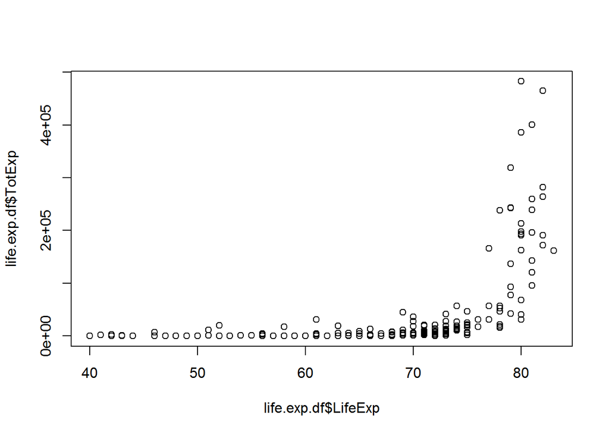

```r
plot(life.exp.df$LifeExp, life.exp.df$TotExp)
```

```r
fit = lm(LifeExp~TotExp, data=life.exp.df)
summary(fit)
```

```
##
## Call:
## lm(formula = LifeExp ~ TotExp, data = life.exp.df)
##
## Residuals:
##     Min      1Q  Median      3Q     Max
## -24.764  -4.778   3.154   7.116  13.292
##
## Coefficients:
##              Estimate Std. Error t value Pr(>|t|)
## (Intercept) 6.475e+01  7.535e-01  85.933  < 2e-16 ***
## TotExp      6.297e-05  7.795e-06   8.079 7.71e-14 ***
## ---
## Signif. codes:  0 '***' 0.001 '**' 0.01 '*' 0.05 '.' 0.1 ' ' 1
##
## Residual standard error: 9.371 on 188 degrees of freedom
## Multiple R-squared:  0.2577, Adjusted R-squared:  0.2537
## F-statistic: 65.26 on 1 and 188 DF,  p-value: 7.714e-14
```

**From the model summary above we can see that residuals are un-evenly distributed. We get R square as 0.25 indiciating poor fit of the model. From the coefficient standard errors it looks like there is not much variability in the coefficient estimation. P values for both hintercept and TotExp variables are significant indicating they are helping in predicting life expectancy variable**

**2. Raise life expectancy to the 4.6 power (i.e., LifeExp^4.6). Raise total expenditures to the 0.06 power (nearly a log transform, TotExp^.06). Plot LifeExp^4.6 as a function of TotExp^.06, and r re-run the simple regression model using the transformed variables. Provide and interpret the F statistics, R^2, standard error, and p-values. Which model is “better?”**

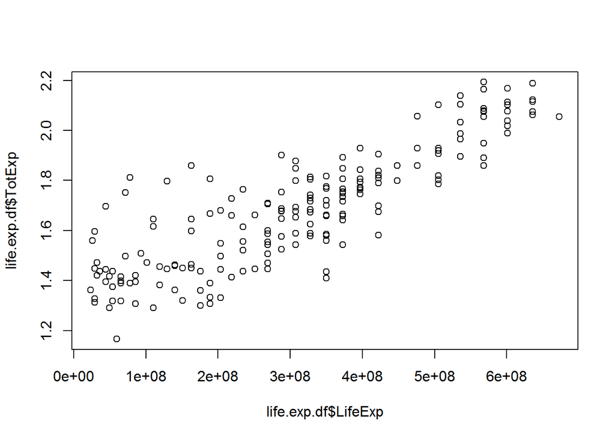

```r
life.exp.df$LifeExp = life.exp.df$LifeExp^4.6
life.exp.df$TotExp = life.exp.df$TotExp^.06
plot(life.exp.df$LifeExp, life.exp.df$TotExp)
```

```r
fit = lm(LifeExp~TotExp, data=life.exp.df)
summary(fit)
```

```
##
## Call:
## lm(formula = LifeExp ~ TotExp, data = life.exp.df)
##
## Residuals:
##        Min         1Q     Median         3Q        Max
## -308616089  -53978977   13697187   59139231  211951764
##
## Coefficients:
##               Estimate Std. Error t value Pr(>|t|)
## (Intercept) -736527910   46817945  -15.73   <2e-16 ***
## TotExp       620060216   27518940   22.53   <2e-16 ***
## ---
## Signif. codes:  0 '***' 0.001 '**' 0.01 '*' 0.05 '.' 0.1 ' ' 1
##
## Residual standard error: 90490000 on 188 degrees of freedom
## Multiple R-squared:  0.7298, Adjusted R-squared:  0.7283
## F-statistic: 507.7 on 1 and 188 DF,  p-value: < 2.2e-16
```

**After transforming the variable we can see that Residuals are evenly distributed. P value estimation is lot better. R Square is increased from 0.25 to 0.72 and F stats is also increased. Certainly model with trnasformed variables is better than the earlier model**

**3. Using the results from 3, forecast life expectancy when TotExp^.06 =1.5. Then forecast life expectancy when TotExp^.06=2.5**

```r
TotExp = c(1.5, 2.5)
test.df = data.frame(TotExp)
life.exp.pred = predict.lm(fit, newdata =test.df)
life.exp.pred = life.exp.pred ^ (1/4.6)
print(life.exp.pred)
```

```
##        1        2
## 63.31153 86.50645
```

**Build the following multiple regression model and interpret the F Statistics, R^2, standard error, and p-values. How good is the model? LifeExp = b0+b1 x PropMd + b2 x TotExp +b3 x PropMD x TotExp**

```r
life.exp.df = read.csv("https://raw.githubusercontent.com/mlforsachid/MSDSQ2Data605/master/Week12/HW-12/who.csv")
life.exp.df$IntTerm = life.exp.df$PropMD * life.exp.df$TotExp
fit = lm(LifeExp~PropMD+TotExp+IntTerm, data=life.exp.df)
summary(fit)
```

```
##
## Call:
## lm(formula = LifeExp ~ PropMD + TotExp + IntTerm, data = life.exp.df)
##
## Residuals:
##     Min      1Q  Median      3Q     Max
## -27.320  -4.132   2.098   6.540  13.074
##
## Coefficients:
##               Estimate Std. Error t value Pr(>|t|)
## (Intercept)  6.277e+01  7.956e-01  78.899  < 2e-16 ***
## PropMD       1.497e+03  2.788e+02   5.371 2.32e-07 ***
## TotExp       7.233e-05  8.982e-06   8.053 9.39e-14 ***
## IntTerm     -6.026e-03  1.472e-03  -4.093 6.35e-05 ***
## ---
## Signif. codes:  0 '***' 0.001 '**' 0.01 '*' 0.05 '.' 0.1 ' ' 1
##
## Residual standard error: 8.765 on 186 degrees of freedom
## Multiple R-squared:  0.3574, Adjusted R-squared:  0.3471
## F-statistic: 34.49 on 3 and 186 DF,  p-value: < 2.2e-16
```

**From the above model summary we can conclude following**

**1. Residuals are not evenly distributed**

**2. P values of all the regression coefficients are significant. This indicates that all the predictor variables are helping in predicting life expectancy**

**3. Make a note of interaction term added to model ProdMD X TotExp. P value of the interaction term is significant indicating it is helpful in predicting life exp**

**4. F statistics is statistically significant. This indicates that one or more variables are statistically significant while poredicting outcome variable (life exp)**

**5. Multiple R Sqaure and Adjusted R square of the model is 0.35 and 0.34 respectively indiciating poor fit of the model**

**Based on R suqare which indicates lack of model fit we can conculde that simple linear regression model with transformed variables is much better that multiple linear regression model**

**5. Forecast LifeExp when PropMD=.03 and TotExp = 14. Does this forecast seem realistic? Why or why not?**

```r
PropMD = c(.03)
TotExp = c(14)
IntTerm = PropMD*TotExp
test.df = data.frame(PropMD, TotExp, IntTerm)
life.exp.pred = predict.lm(fit, newdata =test.df)
print(life.exp.pred)
```

```
##       1
## 107.696
```

**This forecast doesn’t seem realstic. There is very less likelihood of having life expectancy beyond 100 for a given person**